# W3cubDocs

/GTK 4.0

# GtkWindow

GtkWindow — Toplevel which can contain other widgets

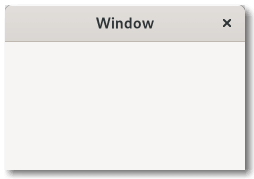

## Functions

| GtkWidget * | gtk_window_new () |
| --- | --- |
| void | gtk_window_destroy () |
| GtkWidget * | gtk_window_get_child () |
| void | gtk_window_set_child () |
| void | gtk_window_set_title () |
| void | gtk_window_set_resizable () |
| gboolean | gtk_window_get_resizable () |
| void | gtk_window_set_modal () |
| void | gtk_window_set_default_size () |
| void | gtk_window_set_hide_on_close () |
| gboolean | gtk_window_get_hide_on_close () |
| void | gtk_window_set_transient_for () |
| void | gtk_window_set_destroy_with_parent () |
| void | gtk_window_set_display () |
| gboolean | gtk_window_is_active () |
| gboolean | gtk_window_is_maximized () |
| gboolean | gtk_window_is_fullscreen () |
| GListModel * | gtk_window_get_toplevels () |
| GList * | gtk_window_list_toplevels () |
| GtkWidget * | gtk_window_get_focus () |
| void | gtk_window_set_focus () |
| GtkWidget * | gtk_window_get_default_widget () |
| void | gtk_window_set_default_widget () |
| void | gtk_window_present () |
| void | gtk_window_present_with_time () |
| void | gtk_window_close () |
| void | gtk_window_minimize () |
| void | gtk_window_unminimize () |
| void | gtk_window_maximize () |
| void | gtk_window_unmaximize () |
| void | gtk_window_fullscreen () |
| void | gtk_window_fullscreen_on_monitor () |
| void | gtk_window_unfullscreen () |
| void | gtk_window_set_decorated () |
| void | gtk_window_set_deletable () |
| void | gtk_window_set_startup_id () |
| gboolean | gtk_window_get_decorated () |
| gboolean | gtk_window_get_deletable () |
| const char * | gtk_window_get_default_icon_name () |
| void | gtk_window_get_default_size () |
| gboolean | gtk_window_get_destroy_with_parent () |
| const char * | gtk_window_get_icon_name () |
| gboolean | gtk_window_get_modal () |
| const char * | gtk_window_get_title () |
| GtkWindow * | gtk_window_get_transient_for () |
| GtkWindowGroup * | gtk_window_get_group () |
| gboolean | gtk_window_has_group () |
| void | gtk_window_set_default_icon_name () |
| void | gtk_window_set_icon_name () |
| void | gtk_window_set_auto_startup_notification () |
| gboolean | gtk_window_get_mnemonics_visible () |
| void | gtk_window_set_mnemonics_visible () |
| gboolean | gtk_window_get_focus_visible () |
| void | gtk_window_set_focus_visible () |
| GtkApplication * | gtk_window_get_application () |
| void | gtk_window_set_application () |
| void | gtk_window_set_titlebar () |
| GtkWidget * | gtk_window_get_titlebar () |
| void | gtk_window_set_interactive_debugging () |

## Properties

| GtkApplication * | application | Read / Write |
| --- | --- | --- |
| GtkWidget * | child | Read / Write |
| gboolean | decorated | Read / Write |
| int | default-height | Read / Write |
| GtkWidget * | default-widget | Read / Write |
| int | default-width | Read / Write |
| gboolean | deletable | Read / Write |
| gboolean | destroy-with-parent | Read / Write |
| [GdkDisplay](https://developer.gnome.org/gtk4/html/GdkDisplay.html#GdkDisplay-struct) * | display | Read / Write |
| gboolean | focus-visible | Read / Write |
| GtkWidget * | focus-widget | Read / Write |
| gboolean | fullscreened | Read / Write / Construct |
| gboolean | hide-on-close | Read / Write |
| char * | icon-name | Read / Write |
| gboolean | is-active | Read |
| gboolean | maximized | Read / Write / Construct |
| gboolean | mnemonics-visible | Read / Write |
| gboolean | modal | Read / Write |
| gboolean | resizable | Read / Write |
| char * | startup-id | Write |
| char * | title | Read / Write |
| GtkWindow * | transient-for | Read / Write / Construct |

## Signals

| void | activate-default | Action |
| --- | --- | --- |
| void | activate-focus | Action |
| gboolean | close-request | Run Last |
| gboolean | enable-debugging | Action |
| void | keys-changed | Run First |

## Actions

|  | window.close |  |
| --- | --- | --- |
|  | window.toggle-maximized |  |
|  | window.minimize |  |
|  | default.activate |  |

## Types and Values

|  | GtkWindow |
| --- | --- |
| struct | GtkWindowClass |

## Object Hierarchy

```
    GObject
    ╰── GInitiallyUnowned
        ╰── GtkWidget
            ╰── GtkWindow
                ├── GtkAboutDialog
                ├── GtkDialog
                ├── GtkApplicationWindow
                ├── GtkAssistant
                ╰── GtkShortcutsWindow
```

## Implemented Interfaces

GtkWindow implements GtkAccessible, GtkBuildable, GtkConstraintTarget, GtkNative, GtkShortcutManager and GtkRoot.

## Includes

```
#include <gtk/gtk.h>
```

## Description

A GtkWindow is a toplevel window which can contain other widgets. Windows normally have decorations that are under the control of the windowing system and allow the user to manipulate the window (resize it, move it, close it,...).

### GtkWindow as GtkBuildable

The GtkWindow implementation of the GtkBuildable interface supports setting a child as the titlebar by specifying “titlebar” as the “type” attribute of a <child> element.

### CSS nodes

```
window.background
├── <child>
╰── <titlebar child>.titlebar [.default-decoration]
```

GtkWindow has a main CSS node with name window and style class .background.

Style classes that are typically used with the main CSS node are .csd (when client-side decorations are in use), .solid-csd (for client-side decorations without invisible borders), .ssd (used by mutter when rendering server-side decorations). GtkWindow also represents window states with the following style classes on the main node: .tiled, .maximized, .fullscreen. Specialized types of window often add their own discriminating style classes, such as .popup or .tooltip.

Generally, some CSS properties don't make sense on the toplevel window node, such as margins or padding. When client-side decorations without invisible borders are in use (i.e. the .solid-csd style class is added to the main window node), the CSS border of the toplevel window is used for resize drags. In the .csd case, the shadow area outside of the window can be used to resize it.

GtkWindow adds the .titlebar and .default-decoration style classes to the widget that is added as a titlebar child.

### Accessibility

GtkWindow uses the `GTK_ACCESSIBLE_ROLE_WINDOW` role.

## Functions

### gtk_window_new ()

```
GtkWidget *
gtk_window_new (void);
```

Creates a new GtkWindow, which is a toplevel window that can contain other widgets.

To get an undecorated window (no window borders), use `gtk_window_set_decorated()`.

All top-level windows created by `gtk_window_new()` are stored in an internal top-level window list. This list can be obtained from `gtk_window_list_toplevels()`. Due to Gtk+ keeping a reference to the window internally, `gtk_window_new()` does not return a reference to the caller.

To delete a GtkWindow, call `gtk_window_destroy()`.

#### Returns

a new GtkWindow.

### gtk_window_destroy ()

```
void
gtk_window_destroy (GtkWindow *window);
```

Drop the internal reference GTK holds on toplevel windows.

#### Parameters

| window | The window to destroy |  |
| --- | --- | --- |

### gtk_window_get_child ()

```
GtkWidget *
gtk_window_get_child (GtkWindow *window);
```

Gets the child widget of *`window`* .

#### Parameters

| window | a GtkWindow |  |
| --- | --- | --- |

#### Returns

the child widget of *`window`* .

[nullable][transfer none]

### gtk_window_set_child ()

```
void
gtk_window_set_child (GtkWindow *window,
                      GtkWidget *child);
```

Sets the child widget of *`window`* .

#### Parameters

| window | a GtkWindow |  |
| --- | --- | --- |
| child | the child widget. | [allow-none] |

### gtk_window_set_title ()

```
void
gtk_window_set_title (GtkWindow *window,
                      const char *title);
```

Passing `NULL` does the same as setting the title to an empty string.

#### Parameters

| window | a GtkWindow |  |
| --- | --- | --- |
| title | title of the window. | [nullable] |

### gtk_window_set_resizable ()

```
void
gtk_window_set_resizable (GtkWindow *window,
                          gboolean resizable);
```

Sets whether the user can resize a window.

Windows are user resizable by default.

#### Parameters

| window | a GtkWindow |  |
| --- | --- | --- |
| resizable | `TRUE` if the user can resize this window |  |

### gtk_window_get_resizable ()

```
gboolean
gtk_window_get_resizable (GtkWindow *window);
```

Gets the value set by `gtk_window_set_resizable()`.

#### Parameters

| window | a GtkWindow |  |
| --- | --- | --- |

#### Returns

`TRUE` if the user can resize the window

### gtk_window_set_modal ()

```
void
gtk_window_set_modal (GtkWindow *window,
                      gboolean modal);
```

Sets a window modal or non-modal. Modal windows prevent interaction with other windows in the same application. To keep modal dialogs on top of main application windows, use `gtk_window_set_transient_for()` to make the dialog transient for the parent; most window managers will then disallow lowering the dialog below the parent.

#### Parameters

| window | a GtkWindow |  |
| --- | --- | --- |
| modal | whether the window is modal |  |

### gtk_window_set_default_size ()

```
void
gtk_window_set_default_size (GtkWindow *window,
                             int width,
                             int height);
```

Sets the default size of a window. If the window’s “natural” size (its size request) is larger than the default, the default will be ignored.

Unlike `gtk_widget_set_size_request()`, which sets a size request for a widget and thus would keep users from shrinking the window, this function only sets the initial size, just as if the user had resized the window themselves. Users can still shrink the window again as they normally would. Setting a default size of -1 means to use the “natural” default size (the size request of the window).

The default size of a window only affects the first time a window is shown; if a window is hidden and re-shown, it will remember the size it had prior to hiding, rather than using the default size.

Windows can’t actually be 0x0 in size, they must be at least 1x1, but passing 0 for *`width`* and *`height`* is OK, resulting in a 1x1 default size.

If you use this function to reestablish a previously saved window size, note that the appropriate size to save is the one returned by `gtk_window_get_default_size()`. Using the window allocation directly will not work in all circumstances and can lead to growing or shrinking windows.

#### Parameters

| window | a GtkWindow |  |
| --- | --- | --- |
| width | width in pixels, or -1 to unset the default width |  |
| height | height in pixels, or -1 to unset the default height |  |

### gtk_window_set_hide_on_close ()

```
void
gtk_window_set_hide_on_close (GtkWindow *window,
                              gboolean setting);
```

If *`setting`* is `TRUE`, then clicking the close button on the window will not destroy it, but only hide it.

#### Parameters

| window | a GtkWindow |  |
| --- | --- | --- |
| setting | whether to hide the window when it is closed |  |

### gtk_window_get_hide_on_close ()

```
gboolean
gtk_window_get_hide_on_close (GtkWindow *window);
```

Returns whether the window will be hidden when the close button is clicked.

#### Parameters

| window | a GtkWindow |  |
| --- | --- | --- |

#### Returns

`TRUE` if the window will be hidden

### gtk_window_set_transient_for ()

```
void
gtk_window_set_transient_for (GtkWindow *window,
                              GtkWindow *parent);
```

Dialog windows should be set transient for the main application window they were spawned from. This allows window managers to e.g. keep the dialog on top of the main window, or center the dialog over the main window. `gtk_dialog_new_with_buttons()` and other convenience functions in GTK will sometimes call `gtk_window_set_transient_for()` on your behalf.

Passing `NULL` for *`parent`* unsets the current transient window.

On Windows, this function puts the child window on top of the parent, much as the window manager would have done on X.

#### Parameters

| window | a GtkWindow |  |
| --- | --- | --- |
| parent | parent window, or `NULL`. | [allow-none] |

### gtk_window_set_destroy_with_parent ()

```
void
gtk_window_set_destroy_with_parent (GtkWindow *window,
                                    gboolean setting);
```

If *`setting`* is `TRUE`, then destroying the transient parent of *`window`* will also destroy *`window`* itself. This is useful for dialogs that shouldn’t persist beyond the lifetime of the main window they're associated with, for example.

#### Parameters

| window | a GtkWindow |  |
| --- | --- | --- |
| setting | whether to destroy *`window`* with its transient parent |  |

### gtk_window_set_display ()

```
void
gtk_window_set_display (GtkWindow *window,
                        GdkDisplay *display);
```

Sets the [GdkDisplay](https://developer.gnome.org/gtk4/html/GdkDisplay.html#GdkDisplay-struct) where the *`window`* is displayed; if the window is already mapped, it will be unmapped, and then remapped on the new display.

#### Parameters

| window | a GtkWindow. |  |
| --- | --- | --- |
| display | a [GdkDisplay](https://developer.gnome.org/gtk4/html/GdkDisplay.html#GdkDisplay-struct). |  |

### gtk_window_is_active ()

```
gboolean
gtk_window_is_active (GtkWindow *window);
```

Returns whether the window is part of the current active toplevel. (That is, the toplevel window receiving keystrokes.) The return value is `TRUE` if the window is active toplevel itself. You might use this function if you wanted to draw a widget differently in an active window from a widget in an inactive window.

#### Parameters

| window | a GtkWindow |  |
| --- | --- | --- |

#### Returns

`TRUE` if the window part of the current active window.

### gtk_window_is_maximized ()

```
gboolean
gtk_window_is_maximized (GtkWindow *window);
```

Retrieves the current maximized state of *`window`* .

Note that since maximization is ultimately handled by the window manager and happens asynchronously to an application request, you shouldn’t assume the return value of this function changing immediately (or at all), as an effect of calling `gtk_window_maximize()` or `gtk_window_unmaximize()`.

If the window isn't yet mapped, the value returned will whether the initial requested state is maximized.

#### Parameters

| window | a GtkWindow |  |
| --- | --- | --- |

#### Returns

whether the window has a maximized state.

### gtk_window_is_fullscreen ()

```
gboolean
gtk_window_is_fullscreen (GtkWindow *window);
```

Retrieves the current fullscreen state of *`window`* .

Note that since fullscreening is ultimately handled by the window manager and happens asynchronously to an application request, you shouldn’t assume the return value of this function changing immediately (or at all), as an effect of calling `gtk_window_fullscreen()` or `gtk_window_unfullscreen()`.

If the window isn't yet mapped, the value returned will whether the initial requested state is fullscreen.

#### Parameters

| window | a GtkWindow |  |
| --- | --- | --- |

#### Returns

whether the window has a fullscreen state.

### gtk_window_get_toplevels ()

```
GListModel *
gtk_window_get_toplevels (void);
```

Returns a list of all existing toplevel windows.

If you want to iterate through the list and perform actions involving callbacks that might destroy the widgets or add new ones, be aware that the list of toplevels will change and emit the "items-changed" signal.

#### Returns

the list of toplevel widgets.

[transfer none][attributes element-type=GtkWindow]

### gtk_window_list_toplevels ()

```
GList *
gtk_window_list_toplevels (void);
```

Returns a list of all existing toplevel windows. The widgets in the list are not individually referenced. If you want to iterate through the list and perform actions involving callbacks that might destroy the widgets, you must call `g_list_foreach (result, (GFunc)g_object_ref, NULL)` first, and then unref all the widgets afterwards.

#### Returns

list of toplevel widgets.

[element-type GtkWidget][transfer container]

### gtk_window_get_focus ()

```
GtkWidget *
gtk_window_get_focus (GtkWindow *window);
```

Retrieves the current focused widget within the window. Note that this is the widget that would have the focus if the toplevel window focused; if the toplevel window is not focused then `gtk_widget_has_focus (widget)` will not be `TRUE` for the widget.

#### Parameters

| window | a GtkWindow |  |
| --- | --- | --- |

#### Returns

the currently focused widget, or `NULL` if there is none.

[nullable][transfer none]

### gtk_window_set_focus ()

```
void
gtk_window_set_focus (GtkWindow *window,
                      GtkWidget *focus);
```

If *`focus`* is not the current focus widget, and is focusable, sets it as the focus widget for the window. If *`focus`* is `NULL`, unsets the focus widget for this window. To set the focus to a particular widget in the toplevel, it is usually more convenient to use `gtk_widget_grab_focus()` instead of this function.

#### Parameters

| window | a GtkWindow |  |
| --- | --- | --- |
| focus | widget to be the new focus widget, or `NULL` to unset any focus widget for the toplevel window. | [allow-none] |

### gtk_window_get_default_widget ()

```
GtkWidget *
gtk_window_get_default_widget (GtkWindow *window);
```

Returns the default widget for *`window`* .

See `gtk_window_set_default_widget()` for more details.

#### Parameters

| window | a GtkWindow |  |
| --- | --- | --- |

#### Returns

the default widget, or `NULL` if there is none.

[nullable][transfer none]

### gtk_window_set_default_widget ()

```
void
gtk_window_set_default_widget (GtkWindow *window,
                               GtkWidget *default_widget);
```

The default widget is the widget that’s activated when the user presses Enter in a dialog (for example). This function sets or unsets the default widget for a GtkWindow.

#### Parameters

| window | a GtkWindow |  |
| --- | --- | --- |
| default_widget | widget to be the default, or `NULL` to unset the default widget for the toplevel. | [allow-none] |

### gtk_window_present ()

```
void
gtk_window_present (GtkWindow *window);
```

Presents a window to the user. This function should not be used as when it is called, it is too late to gather a valid timestamp to allow focus stealing prevention to work correctly.

#### Parameters

| window | a GtkWindow |  |
| --- | --- | --- |

### gtk_window_present_with_time ()

```
void
gtk_window_present_with_time (GtkWindow *window,
                              guint32 timestamp);
```

Presents a window to the user. This may mean raising the window in the stacking order, unminimizing it, moving it to the current desktop, and/or giving it the keyboard focus, possibly dependent on the user’s platform, window manager, and preferences.

If *`window`* is hidden, this function calls `gtk_widget_show()` as well.

This function should be used when the user tries to open a window that’s already open. Say for example the preferences dialog is currently open, and the user chooses Preferences from the menu a second time; use `gtk_window_present()` to move the already-open dialog where the user can see it.

Presents a window to the user in response to a user interaction. The timestamp should be gathered when the window was requested to be shown (when clicking a link for example), rather than once the window is ready to be shown.

#### Parameters

| window | a GtkWindow |  |
| --- | --- | --- |
| timestamp | the timestamp of the user interaction (typically a button or key press event) which triggered this call |  |

### gtk_window_close ()

```
void
gtk_window_close (GtkWindow *window);
```

Requests that the window is closed, similar to what happens when a window manager close button is clicked.

This function can be used with close buttons in custom titlebars.

#### Parameters

| window | a GtkWindow |  |
| --- | --- | --- |

### gtk_window_minimize ()

```
void
gtk_window_minimize (GtkWindow *window);
```

Asks to minimize the specified *`window`* .

Note that you shouldn’t assume the window is definitely minimized afterward, because the windowing system might not support this functionality; other entities (e.g. the user or the window manager) could unminimize it again, or there may not be a window manager in which case minimization isn’t possible, etc.

It’s permitted to call this function before showing a window, in which case the window will be minimized before it ever appears onscreen.

You can track result of this operation via the [“state”](https://developer.gnome.org/gtk4/html/GdkToplevel.html#GdkToplevel--state) property.

#### Parameters

| window | a GtkWindow |  |
| --- | --- | --- |

### gtk_window_unminimize ()

```
void
gtk_window_unminimize (GtkWindow *window);
```

Asks to unminimize the specified *`window`* .

Note that you shouldn’t assume the window is definitely unminimized afterward, because the windowing system might not support this functionality; other entities (e.g. the user or the window manager) could minimize it again, or there may not be a window manager in which case minimization isn’t possible, etc.

You can track result of this operation via the [“state”](https://developer.gnome.org/gtk4/html/GdkToplevel.html#GdkToplevel--state) property.

#### Parameters

| window | a GtkWindow |  |
| --- | --- | --- |

### gtk_window_maximize ()

```
void
gtk_window_maximize (GtkWindow *window);
```

Asks to maximize *`window`* , so that it fills the screen.

Note that you shouldn’t assume the window is definitely maximized afterward, because other entities (e.g. the user or window manager) could unmaximize it again, and not all window managers support maximization.

It’s permitted to call this function before showing a window, in which case the window will be maximized when it appears onscreen initially.

You can track the result of this operation via the [“state”](https://developer.gnome.org/gtk4/html/GdkToplevel.html#GdkToplevel--state) property, or by listening to notifications on the “maximized” property.

#### Parameters

| window | a GtkWindow |  |
| --- | --- | --- |

### gtk_window_unmaximize ()

```
void
gtk_window_unmaximize (GtkWindow *window);
```

Asks to unmaximize *`window`* .

Note that you shouldn’t assume the window is definitely unmaximized afterward, because other entities (e.g. the user or window manager) could maximize it again, and not all window managers honor requests to unmaximize.

You can track the result of this operation via the [“state”](https://developer.gnome.org/gtk4/html/GdkToplevel.html#GdkToplevel--state) property, or by listening to notifications on the “maximized” property.

#### Parameters

| window | a GtkWindow |  |
| --- | --- | --- |

### gtk_window_fullscreen ()

```
void
gtk_window_fullscreen (GtkWindow *window);
```

Asks to place *`window`* in the fullscreen state.

Note that you shouldn’t assume the window is definitely full screen afterward, because other entities (e.g. the user or window manager) could unfullscreen it again, and not all window managers honor requests to fullscreen windows.

You can track the result of this operation via the [“state”](https://developer.gnome.org/gtk4/html/GdkToplevel.html#GdkToplevel--state) property, or by listening to notifications of the “fullscreened” property.

#### Parameters

| window | a GtkWindow |  |
| --- | --- | --- |

### gtk_window_fullscreen_on_monitor ()

```
void
gtk_window_fullscreen_on_monitor (GtkWindow *window,
                                  GdkMonitor *monitor);
```

Asks to place *`window`* in the fullscreen state on the given *`monitor`* .

Note that you shouldn't assume the window is definitely full screen afterward, or that the windowing system allows fullscreen windows on any given monitor.

You can track the result of this operation via the [“state”](https://developer.gnome.org/gtk4/html/GdkToplevel.html#GdkToplevel--state) property, or by listening to notifications of the “fullscreened” property.

#### Parameters

| window | a GtkWindow |  |
| --- | --- | --- |
| monitor | which monitor to go fullscreen on |  |

### gtk_window_unfullscreen ()

```
void
gtk_window_unfullscreen (GtkWindow *window);
```

Asks to remove the fullscreen state for *`window`* , and return to its previous state.

Note that you shouldn’t assume the window is definitely not full screen afterward, because other entities (e.g. the user or window manager) could fullscreen it again, and not all window managers honor requests to unfullscreen windows; normally the window will end up restored to its normal state. Just don’t write code that crashes if not.

You can track the result of this operation via the [“state”](https://developer.gnome.org/gtk4/html/GdkToplevel.html#GdkToplevel--state) property, or by listening to notifications of the “fullscreened” property.

#### Parameters

| window | a GtkWindow |  |
| --- | --- | --- |

### gtk_window_set_decorated ()

```
void
gtk_window_set_decorated (GtkWindow *window,
                          gboolean setting);
```

By default, windows are decorated with a title bar, resize controls, etc. Some window managers allow GTK to disable these decorations, creating a borderless window. If you set the decorated property to `FALSE` using this function, GTK will do its best to convince the window manager not to decorate the window. Depending on the system, this function may not have any effect when called on a window that is already visible, so you should call it before calling `gtk_widget_show()`.

On Windows, this function always works, since there’s no window manager policy involved.

#### Parameters

| window | a GtkWindow |  |
| --- | --- | --- |
| setting | `TRUE` to decorate the window |  |

### gtk_window_set_deletable ()

```
void
gtk_window_set_deletable (GtkWindow *window,
                          gboolean setting);
```

By default, windows have a close button in the window frame. Some window managers allow GTK to disable this button. If you set the deletable property to `FALSE` using this function, GTK will do its best to convince the window manager not to show a close button. Depending on the system, this function may not have any effect when called on a window that is already visible, so you should call it before calling `gtk_widget_show()`.

On Windows, this function always works, since there’s no window manager policy involved.

#### Parameters

| window | a GtkWindow |  |
| --- | --- | --- |
| setting | `TRUE` to decorate the window as deletable |  |

### gtk_window_set_startup_id ()

```
void
gtk_window_set_startup_id (GtkWindow *window,
                           const char *startup_id);
```

Startup notification identifiers are used by desktop environment to track application startup, to provide user feedback and other features. This function changes the corresponding property on the underlying GdkSurface. Normally, startup identifier is managed automatically and you should only use this function in special cases like transferring focus from other processes. You should use this function before calling `gtk_window_present()` or any equivalent function generating a window map event.

This function is only useful on X11, not with other GTK targets.

#### Parameters

| window | a GtkWindow |  |
| --- | --- | --- |
| startup_id | a string with startup-notification identifier |  |

### gtk_window_get_decorated ()

```
gboolean
gtk_window_get_decorated (GtkWindow *window);
```

Returns whether the window has been set to have decorations such as a title bar via `gtk_window_set_decorated()`.

#### Parameters

| window | a GtkWindow |  |
| --- | --- | --- |

#### Returns

`TRUE` if the window has been set to have decorations

### gtk_window_get_deletable ()

```
gboolean
gtk_window_get_deletable (GtkWindow *window);
```

Returns whether the window has been set to have a close button via `gtk_window_set_deletable()`.

#### Parameters

| window | a GtkWindow |  |
| --- | --- | --- |

#### Returns

`TRUE` if the window has been set to have a close button

### gtk_window_get_default_icon_name ()

```
const char *
gtk_window_get_default_icon_name (void);
```

Returns the fallback icon name for windows that has been set with `gtk_window_set_default_icon_name()`, or `NULL` if that function has not been called.

The returned string is owned by GTK and should not be modified. It is only valid until the next call to `gtk_window_set_default_icon_name()`.

#### Returns

the fallback icon name for windows.

[nullable]

### gtk_window_get_default_size ()

```
void
gtk_window_get_default_size (GtkWindow *window,
                             int *width,
                             int *height);
```

Gets the default size of the window. A value of 0 for the width or height indicates that a default size has not been explicitly set for that dimension, so the “natural” size of the window will be used.

#### Parameters

| window | a GtkWindow |  |
| --- | --- | --- |
| width | location to store the default width, or `NULL`. | [out][allow-none] |
| height | location to store the default height, or `NULL`. | [out][allow-none] |

### gtk_window_get_destroy_with_parent ()

```
gboolean
gtk_window_get_destroy_with_parent (GtkWindow *window);
```

Returns whether the window will be destroyed with its transient parent. See `gtk_window_set_destroy_with_parent()`.

#### Parameters

| window | a GtkWindow |  |
| --- | --- | --- |

#### Returns

`TRUE` if the window will be destroyed with its transient parent.

### gtk_window_get_icon_name ()

```
const char *
gtk_window_get_icon_name (GtkWindow *window);
```

Returns the name of the themed icon for the window, see `gtk_window_set_icon_name()`.

#### Parameters

| window | a GtkWindow |  |
| --- | --- | --- |

#### Returns

the icon name or `NULL` if the window has no themed icon.

[nullable]

### gtk_window_get_modal ()

```
gboolean
gtk_window_get_modal (GtkWindow *window);
```

Returns whether the window is modal. See `gtk_window_set_modal()`.

#### Parameters

| window | a GtkWindow |  |
| --- | --- | --- |

#### Returns

`TRUE` if the window is set to be modal and establishes a grab when shown

### gtk_window_get_title ()

```
const char *
gtk_window_get_title (GtkWindow *window);
```

Retrieves the title of the window. See `gtk_window_set_title()`.

#### Parameters

| window | a GtkWindow |  |
| --- | --- | --- |

#### Returns

the title of the window, or `NULL` if none has been set explicitly. The returned string is owned by the widget and must not be modified or freed.

[nullable]

### gtk_window_get_transient_for ()

```
GtkWindow *
gtk_window_get_transient_for (GtkWindow *window);
```

Fetches the transient parent for this window. See `gtk_window_set_transient_for()`.

#### Parameters

| window | a GtkWindow |  |
| --- | --- | --- |

#### Returns

the transient parent for this window, or `NULL` if no transient parent has been set.

[nullable][transfer none]

### gtk_window_get_group ()

```
GtkWindowGroup *
gtk_window_get_group (GtkWindow *window);
```

Returns the group for *`window`* or the default group, if *`window`* is `NULL` or if *`window`* does not have an explicit window group.

#### Parameters

| window | a GtkWindow, or `NULL`. | [allow-none] |
| --- | --- | --- |

#### Returns

the GtkWindowGroup for a window or the default group.

[transfer none]

### gtk_window_has_group ()

```
gboolean
gtk_window_has_group (GtkWindow *window);
```

Returns whether *`window`* has an explicit window group.

#### Parameters

| window | a GtkWindow |  |
| --- | --- | --- |

#### Returns

`TRUE` if *`window`* has an explicit window group.

### gtk_window_set_default_icon_name ()

```
void
gtk_window_set_default_icon_name (const char *name);
```

Sets an icon to be used as fallback for windows that haven't had `gtk_window_set_icon_name()` called on them.

#### Parameters

| name | the name of the themed icon |  |
| --- | --- | --- |

### gtk_window_set_icon_name ()

```
void
gtk_window_set_icon_name (GtkWindow *window,
                          const char *name);
```

Sets the icon for the window from a named themed icon. See the docs for GtkIconTheme for more details. On some platforms, the window icon is not used at all.

Note that this has nothing to do with the WM_ICON_NAME property which is mentioned in the ICCCM.

#### Parameters

| window | a GtkWindow |  |
| --- | --- | --- |
| name | the name of the themed icon. | [allow-none] |

### gtk_window_set_auto_startup_notification ()

```
void
gtk_window_set_auto_startup_notification
                               (gboolean setting);
```

By default, after showing the first GtkWindow, GTK calls [`gdk_display_notify_startup_complete()`](https://developer.gnome.org/gtk4/html/GdkDisplay.html#gdk-display-notify-startup-complete). Call this function to disable the automatic startup notification. You might do this if your first window is a splash screen, and you want to delay notification until after your real main window has been shown, for example.

In that example, you would disable startup notification temporarily, show your splash screen, then re-enable it so that showing the main window would automatically result in notification.

#### Parameters

| setting | `TRUE` to automatically do startup notification |  |
| --- | --- | --- |

### gtk_window_get_mnemonics_visible ()

```
gboolean
gtk_window_get_mnemonics_visible (GtkWindow *window);
```

Gets the value of the “mnemonics-visible” property.

#### Parameters

| window | a GtkWindow |  |
| --- | --- | --- |

#### Returns

`TRUE` if mnemonics are supposed to be visible in this window.

### gtk_window_set_mnemonics_visible ()

```
void
gtk_window_set_mnemonics_visible (GtkWindow *window,
                                  gboolean setting);
```

Sets the “mnemonics-visible” property.

#### Parameters

| window | a GtkWindow |  |
| --- | --- | --- |
| setting | the new value |  |

### gtk_window_get_focus_visible ()

```
gboolean
gtk_window_get_focus_visible (GtkWindow *window);
```

Gets the value of the “focus-visible” property.

#### Parameters

| window | a GtkWindow |  |
| --- | --- | --- |

#### Returns

`TRUE` if “focus rectangles” are supposed to be visible in this window.

### gtk_window_set_focus_visible ()

```
void
gtk_window_set_focus_visible (GtkWindow *window,
                              gboolean setting);
```

Sets the “focus-visible” property.

#### Parameters

| window | a GtkWindow |  |
| --- | --- | --- |
| setting | the new value |  |

### gtk_window_get_application ()

```
GtkApplication *
gtk_window_get_application (GtkWindow *window);
```

Gets the GtkApplication associated with the window (if any).

#### Parameters

| window | a GtkWindow |  |
| --- | --- | --- |

#### Returns

a GtkApplication, or `NULL`.

[nullable][transfer none]

### gtk_window_set_application ()

```
void
gtk_window_set_application (GtkWindow *window,
                            GtkApplication *application);
```

Sets or unsets the GtkApplication associated with the window.

The application will be kept alive for at least as long as it has any windows associated with it (see `g_application_hold()` for a way to keep it alive without windows).

Normally, the connection between the application and the window will remain until the window is destroyed, but you can explicitly remove it by setting the *`application`* to `NULL`.

This is equivalent to calling `gtk_application_remove_window()` and/or `gtk_application_add_window()` on the old/new applications as relevant.

#### Parameters

| window | a GtkWindow |  |
| --- | --- | --- |
| application | a GtkApplication, or `NULL` to unset. | [allow-none] |

### gtk_window_set_titlebar ()

```
void
gtk_window_set_titlebar (GtkWindow *window,
                         GtkWidget *titlebar);
```

Sets a custom titlebar for *`window`* .

A typical widget used here is GtkHeaderBar, as it provides various features expected of a titlebar while allowing the addition of child widgets to it.

If you set a custom titlebar, GTK will do its best to convince the window manager not to put its own titlebar on the window. Depending on the system, this function may not work for a window that is already visible, so you set the titlebar before calling `gtk_widget_show()`.

#### Parameters

| window | a GtkWindow |  |
| --- | --- | --- |
| titlebar | the widget to use as titlebar. | [allow-none] |

### gtk_window_get_titlebar ()

```
GtkWidget *
gtk_window_get_titlebar (GtkWindow *window);
```

Returns the custom titlebar that has been set with `gtk_window_set_titlebar()`.

#### Parameters

| window | a GtkWindow |  |
| --- | --- | --- |

#### Returns

the custom titlebar, or `NULL`.

[nullable][transfer none]

### gtk_window_set_interactive_debugging ()

```
void
gtk_window_set_interactive_debugging (gboolean enable);
```

Opens or closes the interactive debugger, which offers access to the widget hierarchy of the application and to useful debugging tools.

#### Parameters

| enable | `TRUE` to enable interactive debugging |  |
| --- | --- | --- |

## Types and Values

### GtkWindow

```
typedef struct _GtkWindow GtkWindow;
```

### struct GtkWindowClass

```
struct GtkWindowClass {
  GtkWidgetClass parent_class;

  /* G_SIGNAL_ACTION signals for keybindings */

  void     (* activate_focus)   (GtkWindow *window);
  void     (* activate_default) (GtkWindow *window);
  void	   (* keys_changed)     (GtkWindow *window);
  gboolean (* enable_debugging) (GtkWindow *window,
                                 gboolean   toggle);
  gboolean (* close_request)    (GtkWindow *window);
};
```

#### Members

| *`activate_focus`* () | Activates the current focused widget within the window. |  |
| --- | --- | --- |
| *`activate_default`* () | Activates the default widget for the window. |  |
| *`keys_changed`* () | Signal gets emitted when the set of accelerators or mnemonics that are associated with window changes. |  |
| *`enable_debugging`* () | Class handler for the “enable-debugging” keybinding signal. |  |
| *`close_request`* () | Class handler for the “close-request” signal. |  |

## Property Details

### The `“application”` property

```
  “application”              GtkApplication *
```

The GtkApplication associated with the window.

The application will be kept alive for at least as long as it has any windows associated with it (see `g_application_hold()` for a way to keep it alive without windows).

Normally, the connection between the application and the window will remain until the window is destroyed, but you can explicitly remove it by setting the :application property to `NULL`.

Owner: GtkWindow

Flags: Read / Write

### The `“child”` property

```
  “child”                    GtkWidget *
```

The child widget.

Owner: GtkWindow

Flags: Read / Write

### The `“decorated”` property

```
  “decorated”                gboolean
```

Whether the window should be decorated by the window manager.

Owner: GtkWindow

Flags: Read / Write

Default value: TRUE

### The `“default-height”` property

```
  “default-height”           int
```

The default height of the window.

Owner: GtkWindow

Flags: Read / Write

Allowed values: >= -1

Default value: 0

### The `“default-widget”` property

```
  “default-widget”           GtkWidget *
```

The default widget.

Owner: GtkWindow

Flags: Read / Write

### The `“default-width”` property

```
  “default-width”            int
```

The default width of the window.

Owner: GtkWindow

Flags: Read / Write

Allowed values: >= -1

Default value: 0

### The `“deletable”` property

```
  “deletable”                gboolean
```

Whether the window frame should have a close button.

Owner: GtkWindow

Flags: Read / Write

Default value: TRUE

### The `“destroy-with-parent”` property

```
  “destroy-with-parent”      gboolean
```

If this window should be destroyed when the parent is destroyed.

Owner: GtkWindow

Flags: Read / Write

Default value: FALSE

### The `“display”` property

```
  “display”                  GdkDisplay *
```

The display that will display this window.

Owner: GtkWindow

Flags: Read / Write

### The `“focus-visible”` property

```
  “focus-visible”            gboolean
```

Whether 'focus rectangles' are currently visible in this window.

This property is maintained by GTK based on user input and should not be set by applications.

Owner: GtkWindow

Flags: Read / Write

Default value: TRUE

### The `“focus-widget”` property

```
  “focus-widget”             GtkWidget *
```

The focus widget.

Owner: GtkWindow

Flags: Read / Write

### The `“fullscreened”` property

```
  “fullscreened”             gboolean
```

Whether the window is fullscreen.

Setting this property is the equivalent of calling `gtk_window_fullscreen()` and `gtk_window_unfullscreen()`; either operation is asynchronous, which means you will need to connect to the “notify” signal in order to know whether the operation was successful.

Owner: GtkWindow

Flags: Read / Write / Construct

Default value: FALSE

### The `“hide-on-close”` property

```
  “hide-on-close”            gboolean
```

If this window should be hidden when the user clicks the close button.

Owner: GtkWindow

Flags: Read / Write

Default value: FALSE

### The `“icon-name”` property

```
  “icon-name”                char *
```

The :icon-name property specifies the name of the themed icon to use as the window icon. See GtkIconTheme for more details.

Owner: GtkWindow

Flags: Read / Write

Default value: NULL

### The `“is-active”` property

```
  “is-active”                gboolean
```

Whether the toplevel is the current active window.

Owner: GtkWindow

Flags: Read

Default value: FALSE

### The `“maximized”` property

```
  “maximized”                gboolean
```

Whether the window is maximized.

Setting this property is the equivalent of calling `gtk_window_maximize()` and `gtk_window_unmaximize()`; either operation is asynchronous, which means you will need to connect to the “notify” signal in order to know whether the operation was successful.

Owner: GtkWindow

Flags: Read / Write / Construct

Default value: FALSE

### The `“mnemonics-visible”` property

```
  “mnemonics-visible”        gboolean
```

Whether mnemonics are currently visible in this window.

This property is maintained by GTK based on user input, and should not be set by applications.

Owner: GtkWindow

Flags: Read / Write

Default value: FALSE

### The `“modal”` property

```
  “modal”                    gboolean
```

If TRUE, the window is modal (other windows are not usable while this one is up).

Owner: GtkWindow

Flags: Read / Write

Default value: FALSE

### The `“resizable”` property

```
  “resizable”                gboolean
```

If TRUE, users can resize the window.

Owner: GtkWindow

Flags: Read / Write

Default value: TRUE

### The `“startup-id”` property

```
  “startup-id”               char *
```

The :startup-id is a write-only property for setting window's startup notification identifier. See `gtk_window_set_startup_id()` for more details.

Owner: GtkWindow

Flags: Write

Default value: NULL

### The `“title”` property

```
  “title”                    char *
```

The title of the window.

Owner: GtkWindow

Flags: Read / Write

Default value: NULL

### The `“transient-for”` property

```
  “transient-for”            GtkWindow *
```

The transient parent of the window. See `gtk_window_set_transient_for()` for more details about transient windows.

Owner: GtkWindow

Flags: Read / Write / Construct

## Signal Details

### The `“activate-default”` signal

```
void
user_function (GtkWindow *window,
               gpointer   user_data)
```

The ::activate-default signal is a keybinding signal which gets emitted when the user activates the default widget of *`window`* .

#### Parameters

| window | the window which received the signal |  |
| --- | --- | --- |
| user_data | user data set when the signal handler was connected. |  |

Flags: Action

### The `“activate-focus”` signal

```
void
user_function (GtkWindow *window,
               gpointer   user_data)
```

The ::activate-focus signal is a keybinding signal which gets emitted when the user activates the currently focused widget of *`window`* .

#### Parameters

| window | the window which received the signal |  |
| --- | --- | --- |
| user_data | user data set when the signal handler was connected. |  |

Flags: Action

### The `“close-request”` signal

```
gboolean
user_function (GtkWindow *window,
               gpointer   user_data)
```

The ::close-request signal is emitted when the user clicks on the close button of the window.

Return: `TRUE` to stop other handlers from being invoked for the signal

#### Parameters

| window | the window on which the signal is emitted |  |
| --- | --- | --- |
| user_data | user data set when the signal handler was connected. |  |

Flags: Run Last

### The `“enable-debugging”` signal

```
gboolean
user_function (GtkWindow *window,
               gboolean   toggle,
               gpointer   user_data)
```

The ::enable-debugging signal is a keybinding signal which gets emitted when the user enables or disables interactive debugging. When *`toggle`* is `TRUE`, interactive debugging is toggled on or off, when it is `FALSE`, the debugger will be pointed at the widget under the pointer.

The default bindings for this signal are Ctrl-Shift-I and Ctrl-Shift-D.

Return: `TRUE` if the key binding was handled

#### Parameters

| window | the window on which the signal is emitted |  |
| --- | --- | --- |
| toggle | toggle the debugger |  |
| user_data | user data set when the signal handler was connected. |  |

Flags: Action

### The `“keys-changed”` signal

```
void
user_function (GtkWindow *window,
               gpointer   user_data)
```

The ::keys-changed signal gets emitted when the set of accelerators or mnemonics that are associated with *`window`* changes.

#### Parameters

| window | the window which received the signal |  |
| --- | --- | --- |
| user_data | user data set when the signal handler was connected. |  |

Flags: Run First

## Action Details

### The `“window.close”` action

Close the window.

### The `“window.toggle-maximized”` action

Maximize or restore the window.

### The `“default.activate”` action

Activate the default widget.

© 2005–2020 The GNOME Project  
Licensed under the GNU Lesser General Public License version 2.1 or later.  
https://developer.gnome.org/gtk4/4.0/GtkWindow.html